# Lesson 18: Inference for Two Proportions

Preparation

- Word Document
- PDF Document

## Solutions

**Please note that the steps show rounded numbers, but that the final answers to the problems are calculated without rounding.**

Problem

Part

Solution

1

-

$H_0:p_1 = p_2$

2

-

$z = \frac{(\hat{p}_1-\hat{p}_2)-(p_1-p_2)}{\sqrt{\hat{p}(1-\hat{p})(\frac{1}{n_1}+\frac{1}{n_2})}}$  
$\hat{p}_1 = \text{Sample proportion for group 1}$  
$\hat{p}_2 = \text{Sample proportion for group 2}$  
$\hat{p} = \text{Overall sample proportion}$  
$n_1 = \text{Sample size for group 1}$  
$n_2 = \text{Sample size for group 2}$

3

-

$(\hat{p}_1 - \hat{p}_2) \pm z^* \sqrt{\frac{\hat{p}_1(1 - \hat{p}_1)}{n_1} + \frac{\hat{p}_2(1 - \hat{p}_2)}{n_2}}$  
$\hat{p}_1 = \text{Sample proportion for group 1}$  
$\hat{p}_2 = \text{Sample proportion for group 2}$  
$n_1 = \text{Sample size for group 1}$  
$n_2 = \text{Sample size for group 2}$  
$z^* = \text{z value for a confidence interval}$

4

A

$296*0.213=63 >10$  
$251*0.108=27>10$  
$296(1-0.213)=233>10$  
$251(1-0.108)=224>10$

4

B

$H_0:p_1 = p_2$  
$H_0:p_1 \neq p_2$

4

C

$z = 3.309$

4

D

$\text{P-value} = 0.001$

4

E

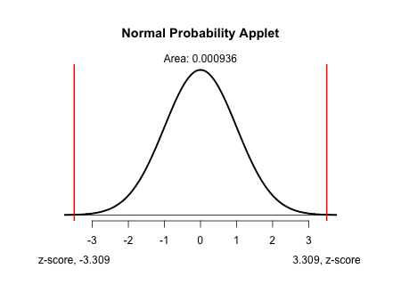

Students should include a sketch of normal distribution curve with both to the left and right of the two z-scores shaded.

4

F

reject the null hypothesis

4

G

We have sufficient evidence to say that there is a difference in the proportions of men who use labels and women who use labels.

5

-

(0.045, 0.165)

6

-

We are 95% confident that the true difference in the proportions of men being label users and women being label users is between 0.045 and 0.165.